# Table of Contents

# Effect of Economic, Social, and Cultural Opportunity on Academic Performance

## by Ken Norton

# Investigation Overview

In this investigation, I wanted to look at how economic, social, and cultural opportunity affects academic performance worldwide.

## Dataset Overview

Around 510,000 students in 65 economies took part in the PISA 2012 assessment of reading, mathematics and science. The dataset included more than 600 dimensions, including an index of how the student's economic, social, and cultural status compared to the broader population.

```python
plt.style.use('fivethirtyeight')
plt.style.use('seaborn-poster')
```

## Countries with the most disadvantaged students

Several countries had > 50% of their students from disadvantaged backgrounds. Indonesia, Turkey, Peru, Brazil, and Thailand had the highest percentage of disadvantaged students.

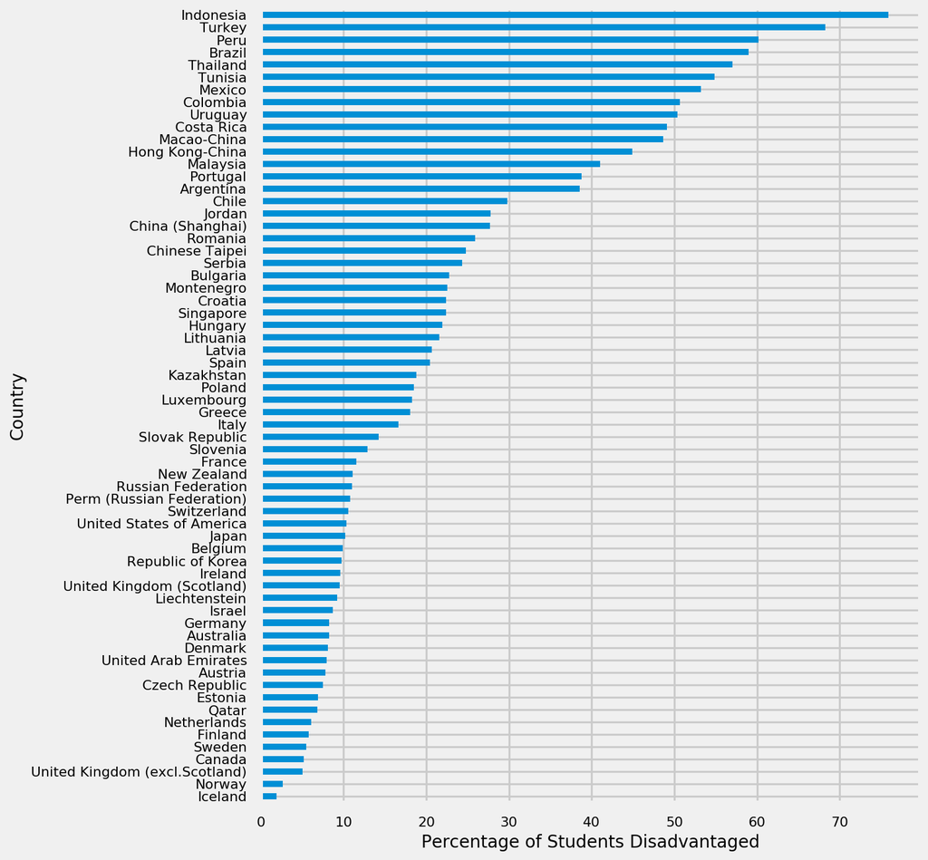

```python
fig, ax = plt.subplots()
fig.set_size_inches(8.5, 11)
dt = (df_clean.query('disadvantaged == 1').groupby('country')['student_id'].count() /
      df_clean.groupby('country')['student_id'].count()).sort_values() * 100
dt.dropna().plot(kind="barh", fontsize=11)
ax.set_ylabel("Country", fontsize=14)
ax.set_xlabel("Percentage of Students Disadvantaged", fontsize=14)
plt.show()
```

## Countries with the most advantaged students

On the other hand, Iceland had by far the largest percentage of advantaged students. No other country had more than 30%. Canada, Qatar, Norway, and Finland rounded out the top five.

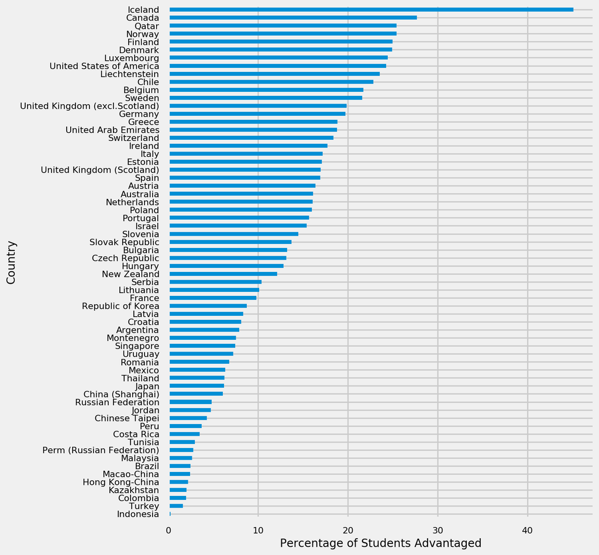

```python
fig, ax = plt.subplots()
fig.set_size_inches(8.5, 11)
dt = (df_clean.query('advantaged == 1').groupby('country')['student_id'].count() /
      df_clean.groupby('country')['student_id'].count()).sort_values() * 100
dt.dropna().plot(kind="barh", fontsize=11)
ax.set_ylabel("Country", fontsize=14)
ax.set_xlabel("Percentage of Students Advantaged", fontsize=14)
plt.show()
```

## Nations with the highest economic, social, and cultural status

When we look at the overall economic, social, and cultural status for each nation, we can see that the top countries are primarily free nations on the *Freedom House* Civil Liberties scale.

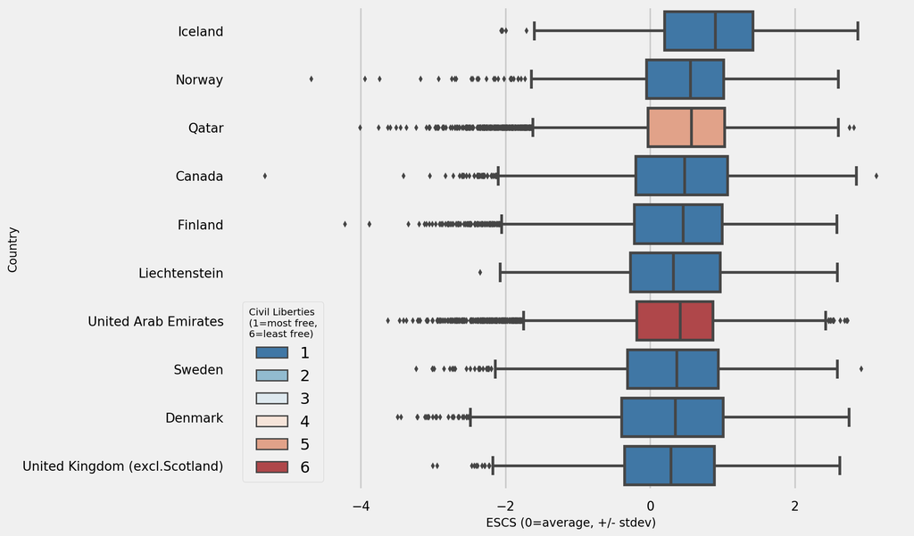

```python
cnt_sort = df_clean.groupby('country')['ESCS'].mean().sort_values(
    ascending=False).dropna().head(10)

fig, ax = plt.subplots()
fig.set_size_inches(11, 8.5)
sns.boxplot(data=df_clean,
            y='country',
            x='ESCS',
            order=cnt_sort.index.get_level_values('country'),
            dodge=False,
            palette='RdBu_r',
            hue='civil_liberties')
ax.set_ylabel("Country", fontsize=12)
ax.set_xlabel("ESCS (0=average, +/- stdev)", fontsize=12)
legend = ax.legend(loc='best', title_fontsize=10).set_title(
    'Civil Liberties\n(1=most free,\n6=least free)')
ax.tick_params(labelsize=13)
plt.show()
```

## Nations with the lowest economic, social, and cultural status

The bottom countries score worse on the *Freedom House* Civil Liberties scale. Costa Rica is the only country in the bottom ten that scores 1 (most free) on this index. We found that freer countries perform better on the overall academic literacy score than less free countries (p=0.00).

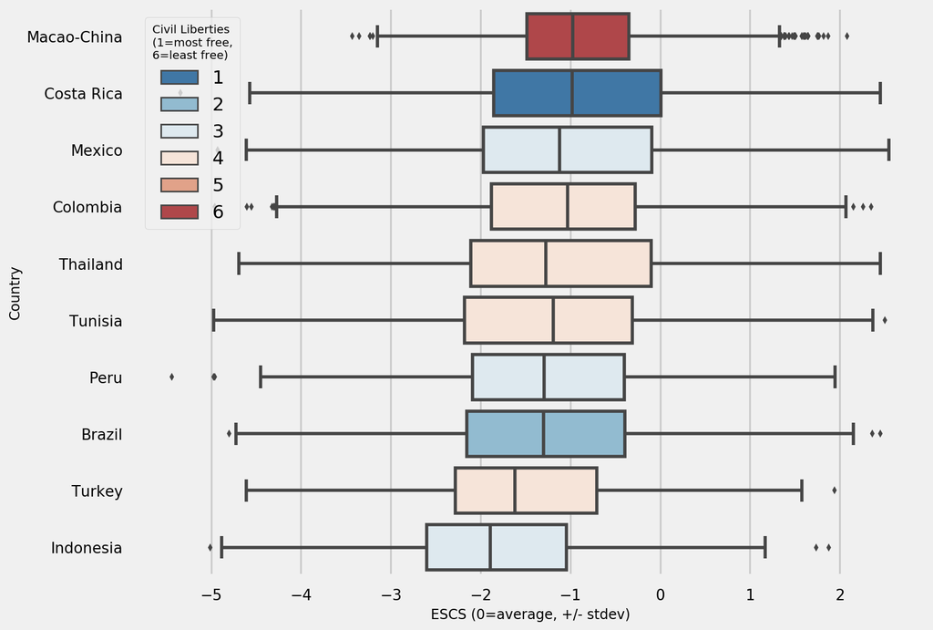

```python
cnt_sort = df_clean.groupby('country')['ESCS'].mean().sort_values(
    ascending=False).dropna().tail(10)

fig, ax = plt.subplots()
fig.set_size_inches(11, 8.5)
sns.boxplot(data=df_clean,
            y='country',
            x='ESCS',
            order=cnt_sort.index.get_level_values('country'),
            dodge=False,
            palette='RdBu_r',
            hue='civil_liberties')
ax.set_ylabel("Country", fontsize=12)
ax.set_xlabel("ESCS (0=average, +/- stdev)", fontsize=12)
legend = ax.legend(loc='best', title_fontsize=10).set_title(
    'Civil Liberties\n(1=most free,\n6=least free)')
ax.tick_params(labelsize=13)
plt.show()
```

## Overall Literacy Scores by Opportunity

We defined children to be "advantaged" if they were +1 or higher standard deviations above the mean in opportunity. They are "disadvantaged" if the are -1 or lower standard deviations below the mean. We can see that children who are advantaged perform better in overall academic literacy and children that are disadvantaged perform worse. This effect is statistically significant (p=0.00).

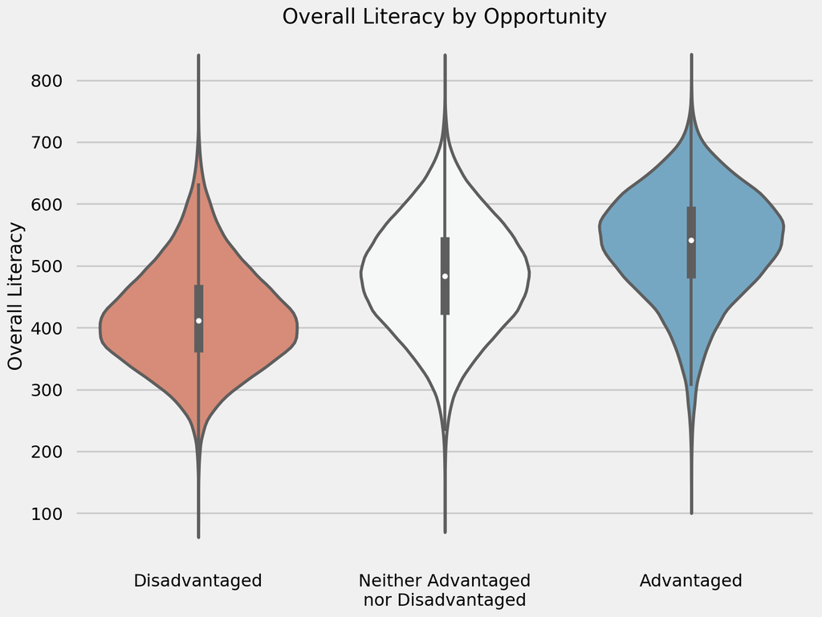

```python
df1 = pd.DataFrame(df.query('disadvantaged == 1'),
                   columns=['overall_literacy']).assign(opp='Disadvantaged')
df2 = pd.DataFrame(df_clean.query('advantaged == 0 and disadvantaged == 0'),
                   columns=['overall_literacy'
                           ]).assign(opp='Neither Advantaged\nnor Disadvantaged')
df3 = pd.DataFrame(df_clean.query('advantaged == 1'),
                   columns=['overall_literacy']).assign(opp='Advantaged')

cdf = pd.concat([df1, df2, df3])

mdf = pd.melt(cdf, id_vars=['opp'], var_name=['overall_literacy'])

fig, ax = plt.subplots()
fig.set_size_inches(11, 8.5)
ax = sns.violinplot(x='opp', y='value', data=mdf, palette='RdBu')
ax.set_xlabel(None)
ax.set_ylabel("Overall Literacy")
ax.set_title("Overall Literacy by Opportunity")
plt.show()
```